# Capstone_Stocks_NLP

## **Problem Statement**

### Business Context

The prices of the stocks of companies listed under a global exchange are influenced by a variety of factors, with the company's financial performance, innovations and collaborations, and market sentiment being factors that play a significant role. News and media reports can rapidly affect investor perceptions and, consequently, stock prices in the highly competitive financial industry. With the sheer volume of news and opinions from a wide variety of sources, investors and financial analysts often struggle to stay updated and accurately interpret its impact on the market. As a result, investment firms need sophisticated tools to analyze market sentiment and integrate this information into their investment strategies.

### Problem Definition

With an ever-rising number of news articles and opinions, an investment startup aims to leverage artificial intelligence to address the challenge of interpreting stock-related news and its impact on stock prices. They have collected historical daily news for a specific company listed under NASDAQ, along with data on its daily stock price and trade volumes.

As a member of the Data Science and AI team in the startup, you have been tasked with analyzing the data, developing an AI-driven sentiment analysis system that will automatically process and analyze news articles to gauge market sentiment, and summarizing the news at a weekly level to enhance the accuracy of their stock price predictions and optimize investment strategies. This will empower their financial analysts with actionable insights, leading to more informed investment decisions and improved client outcomes.

### Data Dictionary

- `Date` : The date the news was released
- `News` : The content of news articles that could potentially affect the company's stock price
- `Open` : The stock price (in \$) at the beginning of the day
- `High` : The highest stock price (in \$) reached during the day
- `Low` : The lowest stock price (in \$) reached during the day
- `Close` : The adjusted stock price (in \$) at the end of the day
- `Volume` : The number of shares traded during the day
- `Label` : The sentiment polarity of the news content
  - 1: positive
  - 0: neutral
  - -1: negative

## **Please read the instructions carefully before starting the project.**

**Note**: If the free-tier GPU of Google Colab is not accessible (due to unavailability or exhaustion of daily limit or other reasons), the following steps can be taken:

Note: im pretty sure there are issues with the data

## **Installing and Importing the necessary libraries**

```python
#should work on its own to replace other blocks..

# installing the sentence-transformers and gensim libraries, along with pandas_ta for technical analysis
!pip install -U sentence-transformers gensim transformers tqdm scikit-learn pandas_ta -q
```

[output not shown]

```python
# math and manipulation
import pandas as pd
import numpy as np

# visualization
import matplotlib.pyplot as plt
import seaborn as sns

# To used time-related functions
import time

#finnancial engineering
import pandas_ta as ta
import yfinance as yf

# To parse JSON data
import json

#gensim for glove

from google.colab import drive
import os
from gensim.models import KeyedVectors

# To create word embeddings
from gensim.models import Word2Vec
from gensim.models import KeyedVectors
from gensim.scripts.glove2word2vec import glove2word2vec

# transformer models
import torch
from sentence_transformers import SentenceTransformer # SentenceTransformer imported after installing huggingface_hub

# modeling
from sklearn.tree import DecisionTreeClassifier
from sklearn.ensemble import RandomForestClassifier
from sklearn.model_selection import GridSearchCV
from sklearn.metrics import confusion_matrix, accuracy_score, f1_score, precision_score, recall_score

# To ignore unnecessary warnings
import warnings
warnings.filterwarnings('ignore')

# Fix for pandas_ta import issue
# This monkey patch replaces the incorrect import in pandas_ta
# with the correct way to access NaN
import numpy

def apply_fix():
    import pandas_ta.momentum.squeeze_pro
    pandas_ta.momentum.squeeze_pro.npNaN = numpy.nan  # Changed NaN to numpy.nan

apply_fix() # Call the function to apply the fix
```

## **Loading the dataset**

```python
from google.colab import drive
drive.mount('/content/drive')
```

Note: there are issues with the data... there were more when i got it. i relabeled almost everything, added rows because i split news from rows into multiple new rows at times, deleted things that would confuse the compputer, did everything i could to capture infomation geopolitical macroeconomic tecnological finnancial legal demographic as well as about the competitive landscape all while reducing noise in little more than 300 rows. all things considered its not bad but could be much better with time and effort

hope you enjoy

```python
data=pd.read_csv('/content/drive/MyDrive/Project - Stock Market News Sentiment Analysis and Summarization/stock_news_cleaned_2.csv')
```

```python
#data=pd.read_csv('/content/drive/MyDrive/Project - Stock Market News Sentiment Analysis and Summarization/stock_news_cleaned.csv')
```

```python
#data = pd.read_csv("/content/drive/MyDrive/Project - Stock Market News Sentiment Analysis and Summarization/stock_news.csv") # Complete the code to read the CSV file.
```

```python
df = data.copy()
```

```python
#i figured out after doing .info this was wrong but i moved it here so when i run things from the start i can skip certain drop downs
df['Date'] = pd.to_datetime(df['Date'])
```

## **Data Overview**

```python
df.head(10)
```

|  | Date | News | Open | High | Low | Close | Volume | Label |
| --- | --- | --- | --- | --- | --- | --- | --- | --- |
| 0 | 2019-01-02 | The tech sector experienced a significant dec... | 41.740002 | 42.244999 | 41.482498 | 40.246914 | 130672400 | -1 |
| 1 | 2019-01-02 | Notable Apple suppliers, including Skyworks, ... | 41.740002 | 42.244999 | 41.482498 | 40.246914 | 130672400 | -1 |
| 2 | 2019-01-02 | Apple lowered its fiscal Q1 revenue guidance ... | 41.740002 | 42.244999 | 41.482498 | 40.246914 | 130672400 | -1 |
| 3 | 2019-01-02 | Apple cut its fiscal first quarter revenue fo... | 41.740002 | 42.244999 | 41.482498 | 40.246914 | 130672400 | -1 |
| 4 | 2019-01-02 | Apple's shares fell 8.5% in post market tradin... | 41.740002 | 42.244999 | 41.482498 | 40.246914 | 130672400 | -1 |
| 5 | 2019-01-02 | This news article reports that yields on long... | 41.740002 | 42.244999 | 41.482498 | 40.246914 | 130672400 | -1 |
| 6 | 2019-01-02 | yields on long-dated U.S. Treasury securities ... | 41.740002 | 42.244999 | 41.482498 | 40.246914 | 130672400 | -1 |
| 7 | 2019-01-02 | Apple's revenue warning led to a decline in U... | 41.740002 | 42.244999 | 41.482498 | 40.246914 | 130672400 | -1 |
| 8 | 2019-01-02 | Apple's revenue warning led to a decline in U... | 41.740002 | 42.244999 | 41.482498 | 40.246914 | 130672400 | -1 |
| 9 | 2019-01-02 | Apple CEO Tim Cook discussed the company's Q1 ... | 41.740002 | 42.244999 | 41.482498 | 40.246914 | 130672400 | -1 |

theres all kinds of stock market news pretaining to apple

```python
df.tail(10)
```

|  | Date | News | Open | High | Low | Close | Volume | Label |
| --- | --- | --- | --- | --- | --- | --- | --- | --- |
| 349 | 2019-04-29 | This news article reports on Spotify's first ... | 51.099998 | 51.492500 | 50.9650 | 49.665138 | 88818800 | 0 |
| 350 | 2019-04-30 | The Czech Finance Ministry is finalizing plan... | 50.764999 | 50.849998 | 49.7775 | 48.708790 | 186139600 | -1 |
| 351 | 2019-04-30 | In early trading, U.S. stock futures were fla... | 50.764999 | 50.849998 | 49.7775 | 48.708790 | 186139600 | -1 |
| 352 | 2019-04-30 | Foxconn's Chairman, Gou, is traveling to the ... | 50.764999 | 50.849998 | 49.7775 | 48.708790 | 186139600 | 0 |
| 353 | 2019-04-30 | In mixed trading on Wall Street, disappointin... | 50.764999 | 50.849998 | 49.7775 | 48.708790 | 186139600 | 0 |
| 354 | 2019-04-30 | Media mogul Oprah Winfrey, known for influenc... | 50.764999 | 50.849998 | 49.7775 | 48.708790 | 186139600 | 0 |
| 355 | 2019-04-30 | European shares fell on Tuesday, with banks u... | 50.764999 | 50.849998 | 49.7775 | 48.708790 | 186139600 | 0 |
| 356 | 2019-04-30 | This article reports that the S&P 500 reached... | 50.764999 | 50.849998 | 49.7775 | 48.708790 | 186139600 | 1 |
| 357 | 2019-04-30 | Apple's earnings report exceeded expectations... | 50.764999 | 50.849998 | 49.7775 | 48.708790 | 186139600 | 1 |
| 358 | 2019-04-30 | The tech giants expect improved results in the... | 50.764999 | 50.849998 | 49.7775 | 48.708790 | 186139600 | 1 |

sometimes it talkes about oprah and we just tell it to ignore oprah

```python
df.shape
```

```
(359, 8)
```

near the end of my second time cleaning the data i realized that in some cases splitting the data rows into multiple article rows was a better idea however i did not do this enough and will not be doing it before the deadline unfortunately although performance would likely be quiteee good

```python
df.isnull().sum()
```

|  | 0 |
| --- | --- |
| Date | 0 |
| News | 0 |
| Open | 0 |
| High | 0 |
| Low | 0 |
| Close | 0 |
| Volume | 0 |
| Label | 0 |

**dtype:** int64

```python
df.duplicated().sum()
```

```
0
```

```python
df.info()
```

```
<class 'pandas.core.frame.DataFrame'>
RangeIndex: 359 entries, 0 to 358
Data columns (total 8 columns):
 #   Column  Non-Null Count  Dtype
---  ------  --------------  -----
 0   Date    359 non-null    datetime64[ns]
 1   News    359 non-null    object
 2   Open    359 non-null    float64
 3   High    359 non-null    float64
 4   Low     359 non-null    float64
 5   Close   359 non-null    float64
 6   Volume  359 non-null    int64
 7   Label   359 non-null    int64
dtypes: datetime64[ns](1), float64(4), int64(2), object(1)
memory usage: 22.6+ KB
```

i already changed it

```python
#df['Date'] = pd.to_datetime(df['Date'])
```

```python
df.describe()
```

|  | Date | Open | High | Low | Close | Volume | Label |
| --- | --- | --- | --- | --- | --- | --- | --- |
| count | 359 | 359.000000 | 359.000000 | 359.000000 | 359.000000 | 3.590000e+02 | 359.000000 |
| mean | 2019-02-15 09:53:38.941504256 | 46.129673 | 46.597834 | 45.650884 | 44.826942 | 1.286184e+08 | -0.200557 |
| min | 2019-01-02 00:00:00 | 37.567501 | 37.817501 | 37.305000 | 36.254131 | 4.544800e+07 | -1.000000 |
| 25% | 2019-01-11 00:00:00 | 41.740002 | 42.244999 | 41.482498 | 40.246914 | 1.035448e+08 | -1.000000 |
| 50% | 2019-02-04 00:00:00 | 43.922501 | 44.480000 | 43.492500 | 42.684212 | 1.156272e+08 | 0.000000 |
| 75% | 2019-03-21 00:00:00 | 49.884998 | 50.845001 | 49.652500 | 49.110790 | 1.481588e+08 | 0.000000 |
| max | 2019-04-30 00:00:00 | 66.817497 | 67.062500 | 65.862503 | 64.805229 | 2.444392e+08 | 1.000000 |
| std | NaN | 6.381277 | 6.445743 | 6.328494 | 6.338401 | 4.266806e+07 | 0.692255 |

theres problems with the quantitative data like closes being lower than low and such

## **Exploratory Data Analysis**

### Univariate Analysis

- Distribution of individual variables
- Compute and check the distribution of the length of news content

```python
#article snippit size
df['news_len'] = df['News'].apply(lambda x: len(x.split(' ')))
df['news_len'].describe()
```

|  | news_len |
| --- | --- |
| count | 359.000000 |
| mean | 46.320334 |
| std | 9.848881 |
| min | 8.000000 |
| 25% | 43.000000 |
| 50% | 49.000000 |
| 75% | 53.000000 |
| max | 61.000000 |

**dtype:** float64

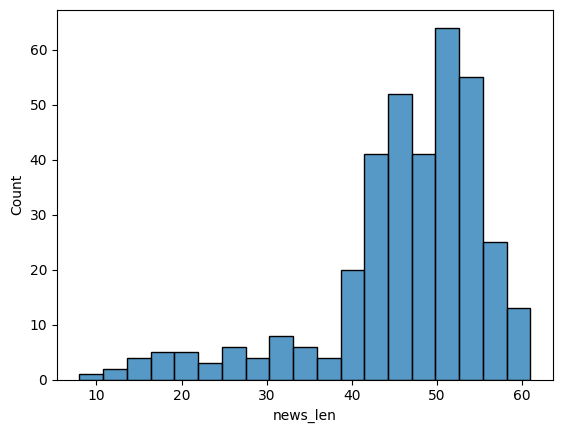

```python
sns.histplot(data=df,x="news_len");
```

most of the short ones are from my augmentatiion efforts

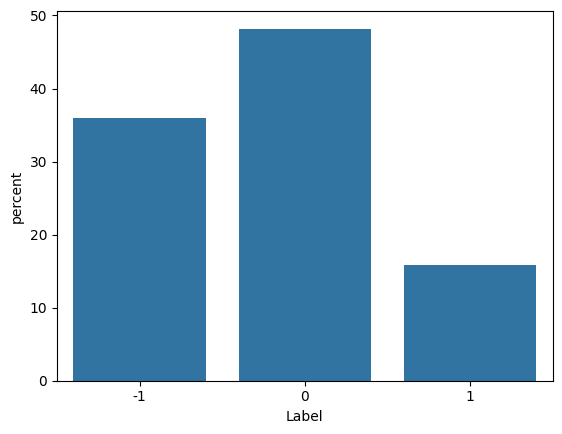

```python
sns.countplot(data=df, x="Label", stat="percent");
```

im a bit of a bear i guess because the labels were originally even between pos neg

Finnancial Engineering:

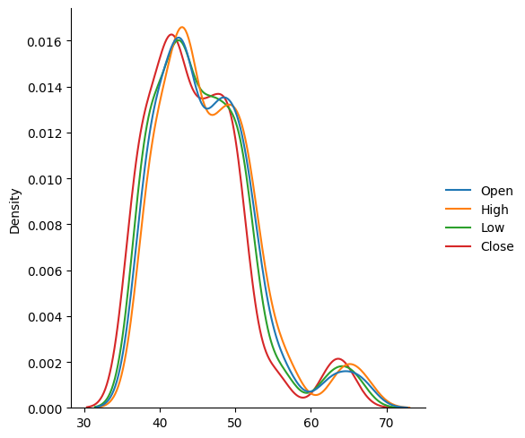

```python
sns.displot(data=df[["Open", "High", "Low", "Close"]], kind="kde", palette="tab10");
```

there are some strong peaks between 40-50 where there is support and resistance. there is a small valley around 47 and a massive one at 60 so there is potential resisance since the stock has traded less frequently here.

traders are buying at like 43 52 and 65 because of support and selling in between the supports and at the end of the fat right tail

there appears to be a breakout or regime cahnge thanks to some possible trend in the news.

there is bimodality and asymitry which indicate a possible trend and lack of random behavior. volititlity seems normal enough given the bimodality. there appears to be some regime change. despite more numbers of negative sentimate in the news the investors clearly saw a buying opportunity or in a higehr dimension analysis of the sentimate the goodnews out weighed the bad or some kind of silver lining/dip as a buying opportunity. the big fat right tail indicates investors saw something. maybe we can learn to figure it out without actually reading the news so we can catch similar opportunities when they arise.

important: this is not finnancial advice these lllms have lots of problemns and the dataset here im pretty sure has its own flaws with labeling...

anyhooo

we saw the pdf now lets look at the cdf

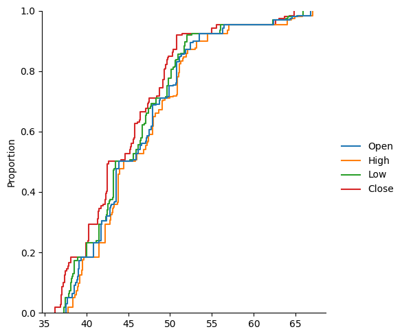

```python
sns.displot(data=df[["Open", "High", "Low", "Close"]], kind="ecdf");
```

literally the same story

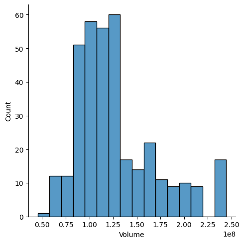

```python
sns.displot(df, x='Volume');
```

x axis is units of 100 million (1e8)

### Bivariate Analysis

- Correlation
- Sentiment Polarity vs Price
- Date vs Price

**Note**: The above points are listed to provide guidance on how to approach bivariate analysis. Analysis has to be done beyond the above listed points to get maximum scores.

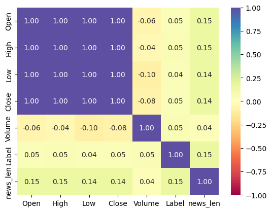

```python
sns.heatmap(
    df.select_dtypes(include=np.number).corr(), annot=True, vmin=-1, vmax=1, fmt=".2f", cmap="Spectral"
);
```

everything looks normal here... prices move together but thats it

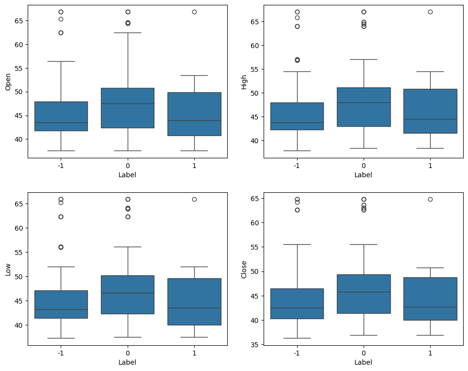

```python
plt.figure(figsize=(10, 8))

for i, variable in enumerate(['Open', 'High', 'Low', 'Close']):
    plt.subplot(2, 2, i + 1)
    sns.boxplot(data=df, x="Label", y=variable)
    plt.tight_layout(pad=2)

plt.show()
```

each outlier represents a single day where the relationship between the news sentiment and price measure are extreme compared to the rest of the data

some news is more impactful

it could also mean that these are errors in our labels

we should examine the outliers to see what kind of news is important

the data is from the trade war period during trump 1 for apple which was delaing with declining sales revenue because of cratering chinese demand lawsuits where they had to pay billions fierce industry competition and government regulations all over the world... a nightmare for an analyst trying to hit golf before markets close

```python
# you can run this later to see what the important news is if its labeled correctly and gets ok performance but you can guess its
# Create a new column 'Outlier' and initialize it to 0
df['Outlier'] = 0

# Iterate through the variables and identify outliers based on the boxplot visualization
for variable in ['Open', 'High', 'Low', 'Close']:
    # Calculate the IQR (Interquartile Range) for each label
    for label in df['Label'].unique():
        Q1 = df[(df['Label'] == label)][variable].quantile(0.25)
        Q3 = df[(df['Label'] == label)][variable].quantile(0.75)
        IQR = Q3 - Q1

        # Define the outlier bounds
        lower_bound = Q1 - 1.5 * IQR
        upper_bound = Q3 + 1.5 * IQR

        # Identify outliers and mark them in the 'Outlier' column
        df.loc[((df['Label'] == label) & ((df[variable] < lower_bound) | (df[variable] > upper_bound))), 'Outlier'] = 1
```

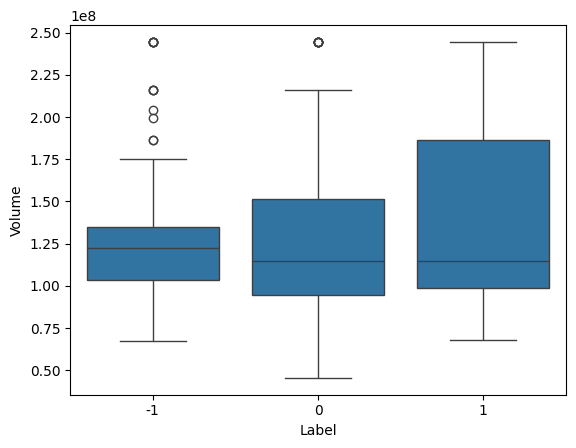

```python
sns.boxplot(
    data=df, x="Label", y="Volume"
);
```

this is interesting youd exppect with all the bearish news money managers would be moving to close out carries and go to bonds gold or francs not what i expected from 2019 and defietely not 2025!

we could also look at the same outliers but for volume to see if they make sense but i need to move on in my story to talk about the priice movement and finnancial engineering

```python
#time series
movement = df.groupby('Date').agg(
    {
        'Open': 'mean',
        'High': 'mean',
        'Low': 'mean',
        'Close': 'mean',
        'Volume': 'mean',
    }
).reset_index()

movement.set_index('Date', inplace=True)
movement.head(25)
```

| Date | Open | High | Low | Close | Volume |
| --- | --- | --- | --- | --- | --- |
| 2019-01-02 | 41.740002 | 42.244999 | 41.482498 | 40.246914 | 130672400.0 |
| 2019-01-03 | 43.570000 | 43.787498 | 43.222500 | 42.470604 | 103544800.0 |
| 2019-01-04 | 47.910000 | 47.919998 | 47.095001 | 46.419842 | 111448000.0 |
| 2019-01-07 | 50.792500 | 51.122501 | 50.162498 | 49.110790 | 109012000.0 |
| 2019-01-08 | 53.474998 | 54.507500 | 51.685001 | 50.787209 | 216071600.0 |
| 2019-01-10 | 56.267502 | 57.055000 | 56.049999 | 54.932766 | 139223200.0 |
| 2019-01-11 | 62.384998 | 63.982498 | 62.290001 | 62.571354 | 151125200.0 |
| 2019-01-14 | 37.712502 | 37.817501 | 37.305000 | 36.254131 | 129756800.0 |
| 2019-01-15 | 37.567501 | 38.347500 | 37.512501 | 36.996128 | 114843600.0 |
| 2019-01-16 | 38.270000 | 38.970001 | 38.250000 | 37.448109 | 122278800.0 |
| 2019-01-17 | 38.549999 | 39.415001 | 38.314999 | 37.670460 | 119284800.0 |
| 2019-01-18 | 39.375000 | 39.470001 | 38.994999 | 37.902481 | 135004000.0 |
| 2019-01-22 | 39.102501 | 39.182499 | 38.154999 | 37.051727 | 121576000.0 |
| 2019-01-23 | 38.537498 | 38.785000 | 37.924999 | 37.201569 | 92522400.0 |
| 2019-01-24 | 38.527500 | 38.619999 | 37.935001 | 36.906708 | 101766000.0 |
| 2019-01-25 | 38.869999 | 39.532501 | 38.580002 | 38.129673 | 134142000.0 |
| 2019-01-28 | 38.947498 | 39.082500 | 38.415001 | 37.776810 | 104768400.0 |
| 2019-01-29 | 39.062500 | 39.532501 | 38.527500 | 37.385262 | 166348800.0 |
| 2019-01-30 | 40.812500 | 41.537498 | 40.057499 | 39.939968 | 244439200.0 |
| 2019-01-31 | 41.527500 | 42.250000 | 41.139999 | 40.227589 | 162958400.0 |
| 2019-02-01 | 38.722500 | 39.712502 | 38.557499 | 38.168350 | 148158800.0 |
| 2019-02-04 | 47.772499 | 48.615002 | 47.762501 | 47.094631 | 91062800.0 |
| 2019-02-05 | 52.459999 | 53.162498 | 52.032501 | 50.767143 | 127985200.0 |
| 2019-02-07 | 50.352501 | 50.782501 | 50.340000 | 49.398319 | 67740800.0 |
| 2019-02-08 | 51.382500 | 51.607498 | 50.407501 | 49.712643 | 163448400.0 |

Why does this matter? do we need more imputation?

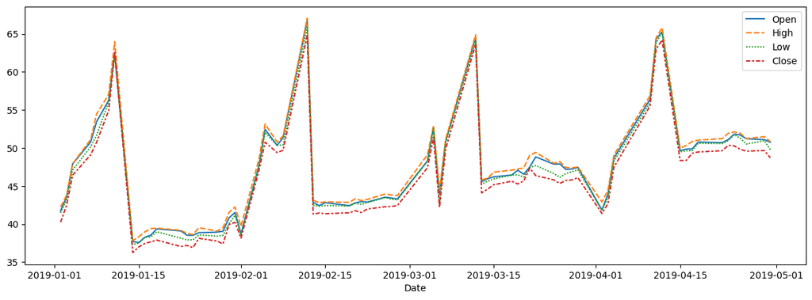

```python
plt.figure(figsize=(15, 5))
sns.lineplot(movement.drop("Volume", axis=1));
```

its slowly going up but with wild fluxuations as investors react to all kinds of news that scares the out of them

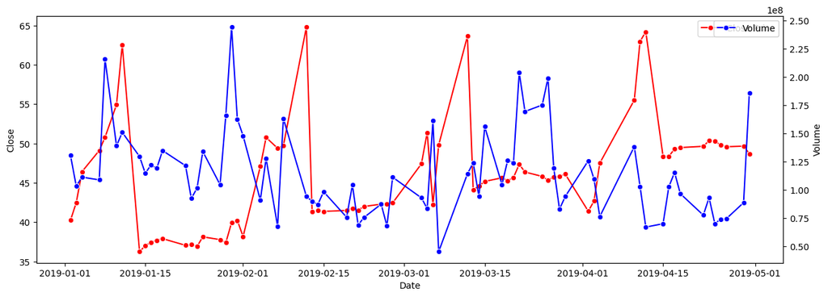

```python
#instantiate visualization
fig, ax1 = plt.subplots(figsize=(15,5))

# Lineplot
sns.lineplot(data=movement.reset_index(), x='Date', y='Close', ax=ax1, color='red', marker='o', label='Close Price')

# Create another y-axis
ax2 = ax1.twinx()

# create a lineplot on the new y axis
sns.lineplot(data=movement.reset_index(), x='Date', y='Volume', ax=ax2, color='blue', marker='o', label='Volume')

ax1.legend(bbox_to_anchor=(1,1));
```

there are several points of divergence where understanding the news sentimate from the most useful snnippits would be crucial. also errors in our labeling could have a disproportionate effect if important news is misclassified by our sentimate guage.

```python
# 1. Calculate SMA 20
df['SMA_20'] = ta.sma(df['Close'], length=20)

# 2. Calculate RSI
df['RSI'] = ta.momentum.rsi(df['Close'], window=14)

# 3. Calculate Stochastics
# Instead of ta.momentum.StochasticOscillator, use ta.stoch
stoch = ta.stoch(high=df['High'], low=df['Low'], close=df['Close'], k=14, d=3)
df['Stochastic_K'] = stoch['STOCHk_14_3_3']
df['Stochastic_D'] = stoch['STOCHd_14_3_3']

# Display the DataFrame with calculated indicators
print(df.head())
```

```
        Date                                               News       Open  \
0 2019-01-02   The tech sector experienced a significant dec...  41.740002
1 2019-01-02   Notable Apple suppliers, including Skyworks, ...  41.740002
2 2019-01-02   Apple lowered its fiscal Q1 revenue guidance ...  41.740002
3 2019-01-02   Apple cut its fiscal first quarter revenue fo...  41.740002
4 2019-01-02  Apple's shares fell 8.5% in post market tradin...  41.740002

        High        Low      Close     Volume  Label  news_len  Outlier  \
0  42.244999  41.482498  40.246914  130672400     -1        17        0
1  42.244999  41.482498  40.246914  130672400     -1        32        0
2  42.244999  41.482498  40.246914  130672400     -1        51        0
3  42.244999  41.482498  40.246914  130672400     -1        51        0
4  42.244999  41.482498  40.246914  130672400     -1        21        0

   SMA_20  RSI  Stochastic_K  Stochastic_D
0     NaN  NaN           NaN           NaN
1     NaN  NaN           NaN           NaN
2     NaN  NaN           NaN           NaN
3     NaN  NaN           NaN           NaN
4     NaN  NaN           NaN           NaN
```

```python
print(df.tail)
```

```
<bound method NDFrame.tail of           Date                                               News       Open  \
0   2019-01-02   The tech sector experienced a significant dec...  41.740002
1   2019-01-02   Notable Apple suppliers, including Skyworks, ...  41.740002
2   2019-01-02   Apple lowered its fiscal Q1 revenue guidance ...  41.740002
3   2019-01-02   Apple cut its fiscal first quarter revenue fo...  41.740002
4   2019-01-02  Apple's shares fell 8.5% in post market tradin...  41.740002
..         ...                                                ...        ...
354 2019-04-30   Media mogul Oprah Winfrey, known for influenc...  50.764999
355 2019-04-30   European shares fell on Tuesday, with banks u...  50.764999
356 2019-04-30   This article reports that the S&P 500 reached...  50.764999
357 2019-04-30   Apple's earnings report exceeded expectations...  50.764999
358 2019-04-30  The tech giants expect improved results in the...  50.764999

          High        Low      Close     Volume  Label  news_len  Outlier  \
0    42.244999  41.482498  40.246914  130672400     -1        17        0
```

[output cut: 25 more lines]

we cant actually use these numbers but we can visualize them

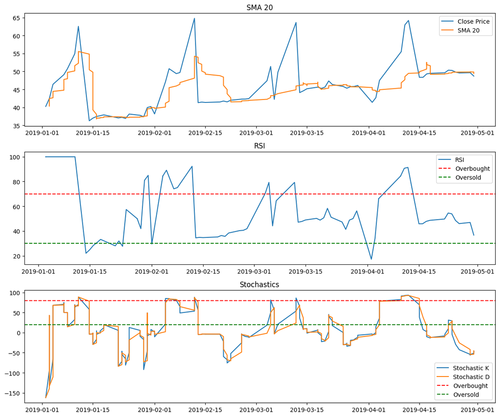

```python
# Create subplots for each indicator
fig, axes = plt.subplots(nrows=3, ncols=1, figsize=(12, 10))

# Plot SMA
axes[0].plot(df['Date'], df['Close'], label='Close Price')
axes[0].plot(df['Date'], df['SMA_20'], label='SMA 20')
axes[0].set_title('SMA 20')
axes[0].legend()

# Plot RSI
axes[1].plot(df['Date'], df['RSI'], label='RSI')
axes[1].axhline(y=70, color='r', linestyle='--', label='Overbought')
axes[1].axhline(y=30, color='g', linestyle='--', label='Oversold')
axes[1].set_title('RSI')
axes[1].legend()

# Plot Stochastics
axes[2].plot(df['Date'], df['Stochastic_K'], label='Stochastic K')
axes[2].plot(df['Date'], df['Stochastic_D'], label='Stochastic D')
axes[2].axhline(y=80, color='r', linestyle='--', label='Overbought')
axes[2].axhline(y=20, color='g', linestyle='--', label='Oversold')
axes[2].set_title('Stochastics')
axes[2].legend()

# Adjust layout and display the plot
plt.tight_layout()
plt.show()
```

there is a lot of volitility here lots of opportunities lots of risk how can we leverege the news to better capitilize on this stock's support and resistence without spending too much time trying to figure out if what trumps sons cousins dog told our boss is true or not

## **Data Preprocessing**

### Split of data accoirding to time

```python
#here we split based on time... hopefully the meaning if it does change due to divergence support resistance will be somehow captured.

X_train = df[(df['Date'] < '2019-04-01')].reset_index() # ~80% of the data
X_val = df[(df['Date'] >= '2019-04-01') & (df['Date'] < '2019-04-20')].reset_index()  # ~20% of the data # Increased validation set size
X_test = df[df['Date'] >= '2019-04-20'].reset_index()   # Remaining data for testing

y_train = X_train["Label"].copy()
y_val = X_val["Label"].copy()
y_test = X_test["Label"].copy()

#Complete the code to print the shape of X_train,X_val,X_test,y_train,y_val and y_test
print("X Train shape",X_train.shape)
print("X Val shape",X_val.shape)
print("X Test shape ",X_test.shape)
print("Y Train shape",y_train.shape)
print("Y Val shape",y_val.shape)
print("Y Test shape ",y_test.shape)
```

[output not shown]

## **Word Embeddings**

### Word2Vec

```python
# Creating a list of all words in our data
words_list = [item.split(" ") for item in df['News'].values]

# Creating an instance of Word2Vec
vec_size = 300
w2v_model = Word2Vec(words_list, vector_size = vec_size, min_count = 1, window=5, workers = 16)

# Checking the size of the vocabulary
print("vocabulary size:", len(list(w2v_model.wv.key_to_index)))
```

```
vocabulary size: 4546
```

Let's check out a few word embeddings obtained using the model.

```python
# Checking the word embedding of a random word
word = "Apple"
w2v_model.wv[word]
```

[output not shown]

```python
# Checking top 5 similar words to the word 'Apple'
similar = w2v_model.wv.similar_by_word('Apple', topn=5)
print(similar)
```

```
[('and', 0.9981985688209534), ('the', 0.998149573802948), ('a', 0.9979377388954163), ('The', 0.9978898763656616), ('of', 0.9978249669075012)]
```

this is only talking about closeness ideally we would want it to pick up on it being similar to microsoft or something so we shouldnt expect much from this given the size of the training set.

```python
# Checking the word embedding of a random word
word = "price"
w2v_model.wv[word]
```

[output not shown]

[output cut: 21 more lines]

```
       -3.81244789e-03, -3.37726884e-02, -1.32874062e-03,  4.51421086e-03,
       -5.19621372e-03,  2.15095393e-02,  5.14768623e-03,  9.59344860e-03,
        1.78858079e-02, -8.09158385e-03, -2.83936244e-02, -1.04910955e-02,
        3.84740718e-02,  1.40455915e-02, -3.23381089e-02, -2.00755149e-02,
        7.21964147e-03,  8.18949565e-03,  1.11386012e-02, -3.40830013e-02,
       -2.41182316e-02,  6.44256687e-03,  1.66435502e-02,  1.44783072e-02,
       -1.72411073e-02,  5.45632793e-03, -8.69857147e-03,  3.72826331e-03,
       -1.76506187e-03, -5.94520243e-03,  1.68057308e-02,  1.22615863e-02,
        1.85341556e-02,  9.82412323e-03, -2.10742038e-02, -6.55622734e-03,
        1.43032335e-02, -1.47801253e-03, -7.85466377e-03,  3.15581635e-03,
       -1.98420836e-03, -1.59254449e-03, -3.28308903e-02,  1.25638647e-02,
        5.19806938e-03,  2.93259155e-02,  1.25202043e-02,  3.00656091e-02,
        1.86705645e-02,  1.42085145e-03,  3.11040618e-02,  3.04089095e-02,
        2.26722285e-03, -1.76016856e-02,  1.84210688e-02, -1.00232251e-02],
      dtype=float32)
```

```python
# Checking top 5 similar words to the word 'price'
similar = w2v_model.wv.similar_by_word('price', topn=5)
print(similar)
```

```
[('and', 0.9914504289627075), ('a', 0.991288423538208), ('in', 0.9912137985229492), ('the', 0.9910869002342224), ('of', 0.9908221960067749)]
```

again the price of the is closer to price than value rate etc....

```python
# Retrieving the words present in the Word2Vec model's vocabulary
words = list(w2v_model.wv.key_to_index.keys())

# Retrieving word vectors for all the words present in the model's vocabulary
word_vectors = w2v_model.wv[words].tolist()

# Creating a dictionary of words and their corresponding vectors
word_vector_dict = dict(zip(words, word_vectors))
```

```python
def average_vectorizer_Word2Vec(doc):
    # Initializing a feature vector for the sentence
    feature_vector = np.zeros((vec_size,), dtype="float64")

    # Creating a list of words in the sentence that are present in the model vocabulary
    words_in_vocab = [word for word in doc.split() if word in words]

    # adding the vector representations of the words
    for word in words_in_vocab:
        feature_vector += np.array(word_vector_dict[word])

    # Dividing by the number of words to get the average vector
    if len(words_in_vocab) != 0:
        feature_vector /= len(words_in_vocab)

    return feature_vector
```

we are mainly doing this for participation points this is not expected to do well on our 300 news snippits

```python
#creating a dataframe of the vectorized documents
#we already split the data based on time because we are dealing with time series data where evolving definitions and understandings play a role for both humans and machines
#we are not doing data leakage
X_train_w2v = pd.DataFrame(X_train["News"].apply(average_vectorizer_Word2Vec).tolist(), columns=['Feature '+str(i) for i in range(vec_size)])
X_val_w2v = pd.DataFrame(X_val["News"].apply(average_vectorizer_Word2Vec).tolist(), columns=['Feature '+str(i) for i in range(vec_size)])
X_test_w2v = pd.DataFrame(X_test["News"].apply(average_vectorizer_Word2Vec).tolist(), columns=['Feature '+str(i) for i in range(vec_size)])
```

```python
print(X_train_w2v.shape, X_val_w2v.shape, X_test_w2v.shape)
```

```
(296, 300) (39, 300) (24, 300)
```

### GloVe

do transformers and w2v together then come back and do this last before moving on to the llm for news sentimate classification and lastly th ellm for weekly news summerization

```python
!pip install gensim
!pip install smart_open

import os
from gensim.models import KeyedVectors
from google.colab import drive

# Mount Google Drive
drive.mount('/content/drive')

# Define the path to your GloVe embeddings on Drive
# Make sure this path is correct and the file exists on your Drive
glove_path = '/content/drive/MyDrive/Project - Stock Market News Sentiment Analysis and Summarization/glove.6B.100d.txt.word2vec'

# Check if the file exists
if os.path.exists(glove_path):
    print("Loading GloVe embeddings from Google Drive...")
    # Load the GloVe embeddings using gensim
    glove_model = KeyedVectors.load_word2vec_format(glove_path, binary=False)  # binary=False for text format
else:
    print(f"GloVe embeddings file not found at: {glove_path}")
    print("Please check the file path and ensure it exists on your Google Drive.")
```

```
Loading GloVe embeddings from Google Drive...
```

```python
# Load the GloVe embeddings using gensim
glove_model = KeyedVectors.load_word2vec_format(glove_path, binary=False)  # binary=False for text format
```

```python
# Checking the size of the vocabulary
print("Length of the vocabulary is", len(glove_model.index_to_key))
```

```
Length of the vocabulary is 400000
```

```python
# Checking the word embedding of a random word
word = "apple"
glove_model[word]
```

```
array([-0.5985   , -0.46321  ,  0.13001  , -0.019576 ,  0.4603   ,
       -0.3018   ,  0.8977   , -0.65634  ,  0.66858  , -0.49164  ,
        0.037557 , -0.050889 ,  0.6451   , -0.53882  , -0.3765   ,
       -0.04312  ,  0.51384  ,  0.17783  ,  0.28596  ,  0.92063  ,
       -0.49349  , -0.48583  ,  0.61321  ,  0.78211  ,  0.19254  ,
        0.91228  , -0.055596 , -0.12512  , -0.65688  ,  0.068557 ,
        0.55629  ,  1.611    , -0.0073642, -0.48879  ,  0.45493  ,
        0.96105  , -0.063369 ,  0.17432  ,  0.9814   , -1.3125   ,
       -0.15801  , -0.54301  , -0.13888  , -0.26146  , -0.3691   ,
        0.26844  , -0.24375  , -0.19484  ,  0.62583  , -0.7377   ,
        0.38351  , -0.75004  , -0.39053  ,  0.091498 , -0.36591  ,
       -1.4715   , -0.45228  ,  0.2256   ,  1.1412   , -0.38526  ,
       -0.06716  ,  0.57288  , -0.39191  ,  0.31302  , -0.29235  ,
       -0.96157  ,  0.15154  , -0.21659  ,  0.25103  ,  0.096967 ,
        0.2843   ,  1.4296   , -0.50565  , -0.51374  , -0.47218  ,
        0.32036  ,  0.023149 ,  0.22623  , -0.09725  ,  0.82126  ,
        0.92599  , -1.0086   , -0.38639  ,  0.86408  , -1.206    ,
       -0.28528  ,  0.2265   , -0.38773  ,  0.40879  ,  0.59303  ,
        0.30769  ,  0.83804  , -0.63655  , -0.44639  , -0.43406  ,
       -0.79364  , -0.28675  , -0.034398 ,  1.3431   ,  0.34904  ],
      dtype=float32)
```

```python
result = glove_model.most_similar("apple", topn=5)
print(result)
```

```
[('microsoft', 0.7449405193328857), ('ibm', 0.6821643114089966), ('intel', 0.6778088212013245), ('software', 0.6775422692298889), ('dell', 0.6741442680358887)]
```

good it understands we want to know about the company it may have just guessed correctly

```python
# Checking the word embedding of a random word
word = "price"
glove_model[word]
```

```
array([ 3.3108e-01,  1.9364e-01,  1.6607e-01,  8.6574e-02, -2.0639e-01,
       -1.4334e+00, -2.9923e-01, -1.1618e-01, -6.6627e-01, -1.4150e-01,
        2.1907e-01,  1.6721e-01, -1.6150e-01, -2.8570e-01,  2.7179e-01,
        9.5956e-02, -9.7168e-01,  1.0444e-01,  1.0485e-01,  1.3673e-01,
        8.3398e-01, -6.8866e-01,  2.6409e-01,  2.9890e-01,  5.9473e-01,
        1.4549e-02,  1.7850e-02, -9.5206e-01, -6.6171e-01, -2.2428e-01,
        3.2354e-01,  5.7278e-01, -7.1502e-02, -1.4367e-01,  3.1574e-01,
        7.4511e-01,  7.5837e-01, -1.7850e-03,  1.0807e-01, -9.9260e-01,
        2.5383e-01, -5.2487e-01, -1.3455e-01, -3.1672e-01,  3.7978e-02,
        4.0723e-01, -5.5722e-01, -1.0508e+00,  5.0940e-03, -1.4605e+00,
        8.2840e-01, -1.4003e-01, -9.2980e-03,  8.4426e-01, -2.6589e-01,
       -2.1714e+00, -5.7227e-02, -1.6759e-01,  2.0411e+00, -2.6865e-01,
        4.3311e-01, -4.7494e-01, -8.3282e-01,  4.2100e-01,  3.4240e-01,
       -5.1296e-01,  6.7027e-01, -2.9009e-01,  7.7592e-01, -1.8930e-01,
       -4.4136e-01, -6.3027e-02, -2.9517e-01,  5.3799e-01, -8.2541e-02,
       -2.5948e-01,  3.1671e-01, -4.3428e-02, -1.1532e+00,  3.7127e-01,
        8.3853e-01,  1.9424e-01, -4.1475e-01, -9.4061e-01, -6.8660e-01,
       -8.6623e-01, -4.4902e-01, -6.0698e-01,  7.7263e-02, -1.6278e-01,
       -4.3910e-01,  4.3965e-01, -1.7207e-01, -6.6014e-01, -1.2322e+00,
        1.6748e-01,  7.3098e-01, -3.3899e-01,  5.9354e-01, -1.6754e-02],
      dtype=float32)
```

```python
result = glove_model.most_similar("price", topn=5)
print(result)
```

```
[('prices', 0.8554712533950806), ('value', 0.760714054107666), ('drop', 0.7485076785087585), ('stock', 0.7451035380363464), ('market', 0.7407819628715515)]
```

this is not guessing it 'understands' the meaning mathematically

```python
# get the words in the GloVe model's vocabulary
glove_words = glove_model.index_to_key

# make a dictionary of our words and their corresponding global vectors
glove_word_vector_dict = dict(zip(glove_model.index_to_key,list(glove_model.vectors)))
```

```python
vec_size=100
```

```python
def average_vectorizer_GloVe(doc):
    # Initializing a feature vector for the sentence
    feature_vector = np.zeros((vec_size,), dtype="float64")

    # Creating a list of words in the sentence that are present in the model vocabulary
    words_in_vocab = [word for word in doc.split() if word in glove_words]

    # adding the vector representations of the words
    for word in words_in_vocab:
        feature_vector += np.array(glove_word_vector_dict[word])

    # Dividing by the number of words to get the average vector
    if len(words_in_vocab) != 0:
        feature_vector /= len(words_in_vocab)

    return feature_vector
```

```python
#applies word embeddings to the splits
X_train_glv = pd.DataFrame(X_train["News"].apply(average_vectorizer_GloVe).tolist(), columns=['Feature '+str(i) for i in range(vec_size)]) #Complete the code to apply GloVe on 'News' column
X_val_glv = pd.DataFrame(X_val["News"].apply(average_vectorizer_GloVe).tolist(), columns=['Feature '+str(i) for i in range(vec_size)]) #Complete the code to apply GloVe on 'News' column
X_test_glv = pd.DataFrame(X_test["News"].apply(average_vectorizer_GloVe).tolist(), columns=['Feature '+str(i) for i in range(vec_size)]) #Complete the code to apply GloVe on 'News' column
```

```python
print(X_train_glv.shape, X_val_glv.shape, X_test_glv.shape)
```

```
(296, 100) (39, 100) (24, 100)
```

### Sentence Transformer

```python
#Defining the model
trans_model = SentenceTransformer('sentence-transformers/all-MiniLM-L6-v2')
```

```python
# setting the device to GPU if available, else CPU
device = torch.device("cuda" if torch.cuda.is_available() else "cpu")
```

```python
X_train_tran = trans_model.encode(X_train["News"].values, show_progress_bar=True, device=device)
X_val_tran = trans_model.encode(X_val["News"].values, show_progress_bar=True, device=device)
X_test_tran = trans_model.encode(X_test["News"].values, show_progress_bar=True, device=device)
```

```python
print(X_train_tran.shape, X_val_tran.shape, X_test_tran.shape)
```

```
(296, 384) (39, 384) (24, 384)
```

## **Sentiment Analysis**

### Utility Functions

```python
def plot_confusion_matrix(model, predictors, target):

    pred = model.predict(predictors)  # Make predictions using the classifier.

    cm = confusion_matrix(target, pred)  # Compute the confusion matrix.

    plt.figure(figsize=(5, 4))  # Create a new figure with a specified size.
    label_list = [0, 1,-1]  # Define the labels for the confusion matrix.
    sns.heatmap(cm, annot=True, fmt='.0f', cmap='Blues', xticklabels=label_list, yticklabels=label_list)
    # Plot the confusion matrix using a heatmap with annotations.

    plt.ylabel('Actual')  # Label for the y-axis.
    plt.xlabel('Predicted')  # Label for the x-axis.
    plt.title('Confusion Matrix')  # Title of the plot.
    plt.show()  # Display the plot.
```

```python
def model_performance_classification_sklearn(model, predictors, target):

    pred = model.predict(predictors)  # Make predictions using the classifier.

    acc = accuracy_score(target, pred)  # Compute Accuracy.
    recall = recall_score(target, pred,average='weighted')  # Compute Recall.
    precision = precision_score(target, pred,average='weighted')  # Compute Precision.
    f1 = f1_score(target, pred,average='weighted')  # Compute F1-score.

    # Create a DataFrame to store the computed metrics.
    df_perf = pd.DataFrame(
        {
            "Accuracy": [acc],
            "Recall": [recall],
            "Precision": [precision],
            "F1": [f1],
        }
    )

    return df_perf  # Return the DataFrame with the metrics.
```

### W2V Model

```python
# Building the model

model_1 = RandomForestClassifier(random_state=42)

# Fitting on train data which is using the vectors
model_1.fit(X_train_w2v, y_train)
```

```
RandomForestClassifier(random_state=42)
```

```python
plot_confusion_matrix(model_1,X_train_w2v,y_train)
```

[output not shown]

[figure not shown]

```python
plot_confusion_matrix(model_1,X_val_w2v,y_val)
```

```python
model_1_train = model_performance_classification_sklearn(model_1,X_train_w2v,y_train)
print("Training performance:\n",model_1_train)
```

```
Training performance:
    Accuracy  Recall  Precision   F1
0       1.0     1.0        1.0  1.0
```

```python
model_1_val = model_performance_classification_sklearn(model_1,X_val_w2v,y_val)
print("Validation performance:\n",model_1_val)
```

```
Validation performance:
    Accuracy    Recall  Precision        F1
0  0.641026  0.641026   0.602051  0.620726
```

### W2V Tuned Model

```python
from sklearn.model_selection import RandomizedSearchCV
```

```python
parameters = {
    'n_estimators': [100, 200, 300, 500],  # Explore a wider range of tree numbers
    'max_depth': [5, 10, 15, None],  # Moderate depth to prevent overfitting, allow for full depth exploration
    'min_samples_split': [2, 5, 10],  # Small values to accommodate small dataset
    'min_samples_leaf': [1, 2, 4],  # Small values to accommodate small dataset
    'max_features': ['sqrt', 'log2', 0.5, 0.7],  # Explore fractional features, and standard options
    'bootstrap': [True, False],
    'class_weight': [None, 'balanced', 'balanced_subsample']
}

# Randomized Search
random_search = RandomizedSearchCV(estimator=RandomForestClassifier(random_state=42),
                                  param_distributions=parameters,
                                  n_iter=100,  # Significantly increased iterations
                                  scoring='f1_weighted',
                                  cv=5,
                                  n_jobs=-1,
                                  verbose=2)
random_search.fit(X_train_w2v, y_train)
model_1_tuned = random_search.best_estimator_

# Train the tuned model
model_1_tuned.fit(X_train_w2v, y_train)
```

```
Fitting 5 folds for each of 100 candidates, totalling 500 fits
```

```
RandomForestClassifier(class_weight='balanced_subsample', max_features=0.7,
                       min_samples_leaf=2, n_estimators=200, random_state=42)
```

```python
plot_confusion_matrix(model_1_tuned,X_train_w2v,y_train)
```

[output not shown]

[figure not shown]

```python
plot_confusion_matrix(model_1_tuned,X_val_w2v,y_val)
```

```python
model_1_tuned_train = model_performance_classification_sklearn(model_1_tuned,X_train_w2v,y_train)
print("Training performance:\n",model_1_tuned_train, )
```

```
Training performance:
    Accuracy  Recall  Precision   F1
0       1.0     1.0        1.0  1.0
```

```python
model_1_tuned_val = model_performance_classification_sklearn(model_1_tuned,X_val_w2v,y_val)
print("Validation performance:\n",model_1_tuned_val)
```

```
Validation performance:
    Accuracy    Recall  Precision        F1
0  0.717949  0.717949   0.716298  0.716502
```

### GloVe Model

```python
# Building the model

model_2 = RandomForestClassifier(random_state=42)

# Fitting on train data which is using the vectors
model_2.fit(X_train_glv, y_train)
```

```
RandomForestClassifier(random_state=42)
```

```python
plot_confusion_matrix(model_2,X_train_glv,y_train)
```

[output not shown]

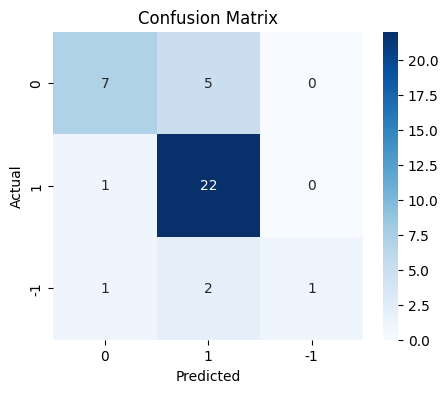

```python
plot_confusion_matrix(model_2,X_val_glv,y_val)
```

```python
model_2_train = model_performance_classification_sklearn(model_2,X_train_glv,y_train)
print("Training performance:\n",model_2_train)
```

```
Training performance:
    Accuracy  Recall  Precision   F1
0       1.0     1.0        1.0  1.0
```

```python
model_2_val = model_performance_classification_sklearn(model_2,X_val_glv,y_val)
print("Validation performance:\n",model_2_val)
```

```
Validation performance:
    Accuracy    Recall  Precision        F1
0  0.769231  0.769231   0.789272  0.745168
```

the plain old glove random forrest immediately better results as the random fine tuned word to vec model using properly labeled and more clean data. tuning this the same way should make it even better

### Tuned GloVe Model

```python
parameters = {
    'n_estimators': [100, 200, 300, 500],  # Explore a wider range of tree numbers
    'max_depth': [5, 10, 15, None],  # Moderate depth to prevent overfitting, allow for full depth exploration
    'min_samples_split': [2, 5, 10],  # Small values to accommodate small dataset
    'min_samples_leaf': [1, 2, 4],  # Small values to accommodate small dataset
    'max_features': ['sqrt', 'log2', 0.5, 0.7],  # Explore fractional features, and standard options
    'bootstrap': [True, False],
    'class_weight': [None, 'balanced', 'balanced_subsample']
}

# Randomized Search
random_search = RandomizedSearchCV(estimator=RandomForestClassifier(random_state=42),
                                  param_distributions=parameters,
                                  n_iter=100,  # Significantly increased iterations
                                  scoring='f1_weighted',
                                  cv=5,
                                  n_jobs=-1,
                                  verbose=2)
random_search.fit(X_train_glv, y_train)
model_2_tuned = random_search.best_estimator_

# Train the tuned model
model_2_tuned.fit(X_train_glv, y_train)
```

```
Fitting 5 folds for each of 100 candidates, totalling 500 fits
```

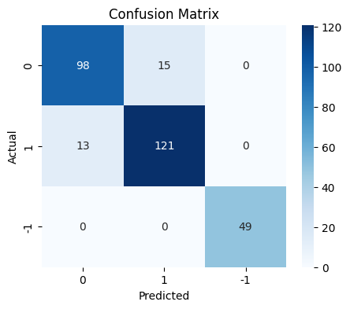

```python
plot_confusion_matrix(model_2_tuned,X_train_glv,y_train)
```

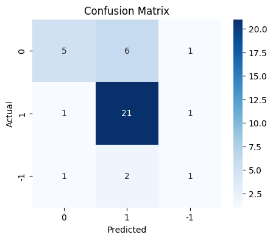

```python
plot_confusion_matrix(model_2_tuned,X_val_glv,y_val)
```

```python
model_2_tuned_train = model_performance_classification_sklearn(model_2_tuned,X_train_glv,y_train)
print("Training performance:\n",model_2_tuned_train)
```

```
Training performance:
    Accuracy    Recall  Precision        F1
0  0.905405  0.905405   0.905359  0.905333
```

```python
model_2_tuned_val = model_performance_classification_sklearn(model_2_tuned,X_val_glv,y_val)
print("Validation performance:\n",model_2_tuned_val)
```

```
Validation performance:
    Accuracy    Recall  Precision        F1
0  0.692308  0.692308   0.681024  0.667579
```

performance dropped but it is generalizing better.

### Transformer Model

```python
# Building the model

model_3 = RandomForestClassifier(random_state=42)

# Fitting on train data which is using the vectors
model_3.fit(X_train_tran, y_train)
```

```
RandomForestClassifier(random_state=42)
```

```python
plot_confusion_matrix(model_3,X_train_tran,y_train)
```

[output not shown]

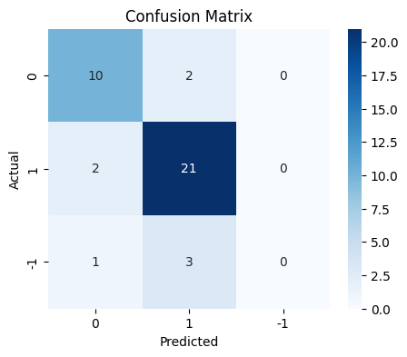

```python
plot_confusion_matrix(model_3,X_val_tran,y_val)
```

```python
model_3_train = model_performance_classification_sklearn(model_3,X_train_tran,y_train)
print("Training performance:\n",model_3_train)
```

```
Training performance:
    Accuracy  Recall  Precision   F1
0       1.0     1.0        1.0  1.0
```

```python
model_3_val = model_performance_classification_sklearn(model_3,X_val_tran,y_val)
print("Validation performance:\n",model_3_val)
```

```
Validation performance:
    Accuracy    Recall  Precision        F1
0  0.794872  0.794872   0.713018  0.751648
```

### Tuned Transformer Model

```python
parameters = {
    'n_estimators': [100, 200, 300, 500],  # Explore a wider range of tree numbers
    'max_depth': [5, 10, 15, None],  # Moderate depth to prevent overfitting, allow for full depth exploration
    'min_samples_split': [2, 5, 10],  # Small values to accommodate small dataset
    'min_samples_leaf': [1, 2, 4],  # Small values to accommodate small dataset
    'max_features': ['sqrt', 'log2', 0.5, 0.7],  # Explore fractional features, and standard options
    'bootstrap': [True, False],
    'class_weight': [None, 'balanced', 'balanced_subsample']
}

# Randomized Search
random_search = RandomizedSearchCV(estimator=RandomForestClassifier(random_state=42),
                                  param_distributions=parameters,
                                  n_iter=100,  # Significantly increased iterations
                                  scoring='f1_weighted',
                                  cv=5,
                                  n_jobs=-1,
                                  verbose=2)
random_search.fit(X_train_tran, y_train)
model_3_tuned = random_search.best_estimator_

# Train the tuned model
model_3_tuned.fit(X_train_tran, y_train)
```

```
Fitting 5 folds for each of 100 candidates, totalling 500 fits
```

```
RandomForestClassifier(bootstrap=False, class_weight='balanced_subsample',
                       max_features='log2', min_samples_split=10,
                       n_estimators=200, random_state=42)
```

```python
plot_confusion_matrix(model_3_tuned,X_train_tran,y_train)
```

[output not shown]

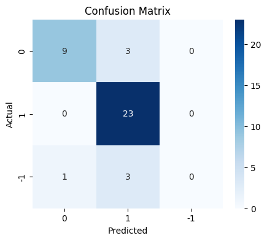

```python
plot_confusion_matrix(model_3_tuned,X_val_tran,y_val)
```

```python
model_3_tuned_train = model_performance_classification_sklearn(model_3_tuned,X_train_tran,y_train)
print("Training performance:\n",model_3_tuned_train)
```

```
Training performance:
    Accuracy  Recall  Precision   F1
0       1.0     1.0        1.0  1.0
```

```python
model_3_tuned_val = model_performance_classification_sklearn(model_3_tuned,X_val_tran,y_val)
print("Validation performance:\n",model_3_tuned_val)
```

```
Validation performance:
    Accuracy    Recall  Precision        F1
0  0.820513  0.820513   0.744651  0.773445
```

we need to see if there is a pattern to what we are getting wrong...

```python
#i need to examine the news we get wrong to see if there are trend reversals or anything that is impacting the model that the model cant be blamed for before we do fine tuning...
misclassified_indices = (model_3_tuned.predict(X_test_tran) != y_test)
misclassified_news = X_test[misclassified_indices]['News']

# Create a DataFrame for better presentation (optional)
misclassified_df = pd.DataFrame({'News': misclassified_news})

# Export to CSV
misclassified_df.to_csv('misclassified_news.csv', index=False)

# Optionally export to JSON
misclassified_df.to_json('misclassified_news.json', orient='records')

print("Misclassified news saved to misclassified_news.csv and misclassified_news.json")
```

```
Misclassified news saved to misclassified_news.csv and misclassified_news.json
```

no pattern really other than me being lazy with the cleaning and labeling...

### Production Model Test

```python
model_3_tuned_test = model_performance_classification_sklearn(model_3_tuned,X_test_tran,y_test)
print("Test performance:\n",model_3_tuned_test)
```

```
Test performance:
    Accuracy    Recall  Precision        F1
0  0.708333  0.708333   0.779762  0.699242
```

eessionially the hard part here is the labeling data cleaning and stuff i think i did a good enough job to turn this on but in the future i plan on doubling the rows with syntheitic data to carefully capture more macroeconomic geopolitical market fundamentals finnancial health info as well as a sense of technology supply chains and industry specific knowledge and the competitive landscape but i have to turn in something and the deadline is approaching... i still have to work out some major kinks in the summerization section....

we can also try an llm that was finetuned to do finnancial news sentimente analysis just like this and see how it does but the labeling crucial to the models is specific to apple during a specific historical backtesting peroiod with specific problems relating to legal geopolitical macroeconomic supply chain and such

## **Sentiment Analysis Using a finetuned llm**

**Important Note**: It is recommended to run this section of the project independently from the previous sections in order to avoid runtime crashes due to RAM overload.

i found this thing online which was trained to do something similar but with a different kind of company in a different time and place with different aspirations. this is just for fun i dont reccomend using something you dont understand how it works.

this thing has lables that say neutral moderately pos/neg, pos/neg themselves , AND mildly pos/neg i have no idea what that means or what goes into those scorings but it does give me ideas about how i might approach my own situation later down th eline.

```python
!pip install transformers peft sentencepiece accelerate torch datasets bitsandbytes
```

[output not shown]

```python
import pandas as pd
import torch
from transformers import AutoTokenizer, AutoModelForCausalLM, pipeline
from peft import PeftModel
import bitsandbytes as bnb
import gc
from sklearn.metrics import confusion_matrix, accuracy_score, precision_score, recall_score, f1_score


# Load the base model and tokenizer
base_model = "NousResearch/Llama-2-13b-hf"
tokenizer = AutoTokenizer.from_pretrained(base_model, trust_remote_code=True)
tokenizer.pad_token = tokenizer.eos_token

# Check GPU availability and set device accordingly
if torch.cuda.is_available():
    device = torch.device("cuda")
else:
    device = torch.device("cpu")

# Define a garbage collection function
def force_gc():
    gc.collect()
    torch.cuda.empty_cache()

# Load Model with CPU Offloading
with torch.no_grad():
    model = AutoModelForCausalLM.from_pretrained(
        base_model,
        trust_remote_code=True,
        torch_dtype=torch.float16,
        load_in_8bit=True,
        device_map="auto",
        llm_int8_enable_fp32_cpu_offload=True
    )

    # Load LoRA after the base model
    peft_model = "FinGPT/fingpt-sentiment_llama2-13b_lora"
    model = PeftModel.from_pretrained(model, peft_model, torch_dtype=torch.float16)

    model.eval()
    force_gc()
```

```
The `load_in_4bit` and `load_in_8bit` arguments are deprecated and will be removed in the future versions. Please, pass a `BitsAndBytesConfig` object in `quantization_config` argument instead.
```

```python
# # uncomment and run the following code if Google Colab is being used and the dataset is in Google Drive
from google.colab import drive
drive.mount('/content/drive')
```

```python
!pip install --upgrade numpy
!pip install --upgrade pandas #Upgrade pandas to ensure compatibility with the upgraded NumPy
import numpy as np
import pandas as pd
```

[output not shown]

```python
df["Date"] = pd.to_datetime(df['Date'])  # Convert the 'Date' column to datetime format.
```

```python
#here we split based on time... hopefully the meaning if it does change due to divergence support resistance will be somehow captured.

X_train = df[(df['Date'] < '2019-04-01')].reset_index() # ~80% of the data
X_val = df[(df['Date'] >= '2019-04-01') & (df['Date'] < '2019-04-20')].reset_index()  # ~20% of the data # Increased validation set size
X_test = df[df['Date'] >= '2019-04-20'].reset_index()   # Remaining data for testing

y_train = X_train["Label"].copy()
y_val = X_val["Label"].copy()
y_test = X_test["Label"].copy()

#Complete the code to print the shape of X_train,X_val,X_test,y_train,y_val and y_test
print("X Train shape",X_train.shape)
print("X Val shape",X_val.shape)
print("X Test shape ",X_test.shape)
print("Y Train shape",y_train.shape)
print("Y Val shape",y_val.shape)
print("Y Test shape ",y_test.shape)
```

```
X Train shape (296, 9)
X Val shape (39, 9)
X Test shape  (24, 9)
Y Train shape (296,)
Y Val shape (39,)
Y Test shape  (24,)
```

```python
# Label Mapping because the model was trained different
label_mapping = {
    "positive": 1,
    "negative": -1,
    "moderately positive": 1,
    "moderately negative": -1,
    "slightly positive": 1,
    "slightly negative": -1,
    "neutral": 0
}
```

```python
# Function to extract sentiment
import re
def extract_sentiment_from_text(text):
    if re.search(r"positive|moderately positive|slightly positive", text, re.IGNORECASE):
        return "positive"
    elif re.search(r"negative|moderately negative|slightly negative", text, re.IGNORECASE):
        return "negative"
    else:
        return "neutral"
```

```python
# Prediction Function (with label mapping)
def predict_sentiment(text):
       preprocessed_text = text # Keep the same preprocessing
       inputs = tokenizer(preprocessed_text, return_tensors="pt").to(device)
       with torch.no_grad():
           outputs = model.generate(**inputs, max_new_tokens=5)
           generated_text = tokenizer.decode(outputs[0], skip_special_tokens=True)
           sentiment_label = extract_sentiment_from_text(generated_text)
           mapped_label = label_mapping.get(sentiment_label, 0)
       return mapped_label
```

```python
# Apply prediction and generate confusion matrices
def evaluate_and_print_results(X, y, dataset_name):
    predictions = X['News'].apply(predict_sentiment).tolist()
    cm = confusion_matrix(y, predictions)

    print(f"Confusion Matrix for {dataset_name}:")
    print(cm)

    accuracy = accuracy_score(y, predictions)
    precision = precision_score(y, predictions, average='weighted')
    recall = recall_score(y, predictions, average='weighted')
    f1 = f1_score(y, predictions, average='weighted')

    print(f"{dataset_name} Accuracy: {accuracy:.4f}")
    print(f"{dataset_name} Precision: {precision:.4f}")
    print(f"{dataset_name} Recall: {recall:.4f}")
    print(f"{dataset_name} F1-Score: {f1:.4f}")
    print("-" * 30)
```

```python
# Evaluate on training and validation sets
evaluate_and_print_results(X_train, y_train, "Training")
evaluate_and_print_results(X_val, y_val, "Validation")
```

```
Confusion Matrix for Training:
[[  4 108   1]
 [  0 131   3]
 [  0  41   8]]
Training Accuracy: 0.4831
Training Precision: 0.7039
Training Recall: 0.4831
Training F1-Score: 0.3560
------------------------------
Confusion Matrix for Validation:
[[ 0 12  0]
 [ 0 23  0]
 [ 0  3  1]]
Validation Accuracy: 0.6154
Validation Precision: 0.4595
Validation Recall: 0.6154
Validation F1-Score: 0.4858
------------------------------
```

## **Weekly News Summary**

#### Installing and Importing the necessary libraries

```python
%env PYTHONSTARTUP=-Xfrozen_modules=off
```

```
env: PYTHONSTARTUP=-Xfrozen_modules=off
```

```python
import os
os.environ['PYDEVD_DISABLE_FILE_VALIDATION'] = '1'
```

```python
!source my_env/bin/activate  # Activate the virtual environment
```

```
/bin/bash: line 1: my_env/bin/activate: No such file or directory
```

```python
# Installation for GPU llama-cpp-python
# uncomment and run the following code in case GPU is being used
!CMAKE_ARGS="-DLLAMA_CUBLAS=on" FORCE_CMAKE=1 pip install llama-cpp-python==0.1.85 --force-reinstall --no-cache-dir -q

# Installation for CPU llama-cpp-python
# uncomment and run the following code in case GPU is not being used
#!CMAKE_ARGS="-DLLAMA_CUBLAS=off" FORCE_CMAKE=1 pip install llama-cpp-python==0.1.85 --force-reinstall --no-cache-dir -q
```

[output not shown]

```python
# Function to download the model from the Hugging Face model hub
from huggingface_hub import hf_hub_download

# Importing the Llama class from the llama_cpp module
from llama_cpp import Llama

# Importing the library for data manipulation
import pandas as pd

from tqdm import tqdm # For progress bar related functionalities
tqdm.pandas()
```

#### Loading the data

```python
from google.colab import drive
drive.mount('/content/drive')
```

```python
data = pd.read_csv("/content/drive/MyDrive/Project - Stock Market News Sentiment Analysis and Summarization/stock_news_cleaned_2.csv") #Complete the code to load the dataset
```

```python
df = data.copy()
```

this model is not finetuined on any of my favorit money managers or textbooks so theres limits to what we can accomplish

for this project the goal is more humble:

prompt the llm to identify the top (three) positive and negative events from the week that are likely to impact the stock price and store it in an organized manner so that the human analyst can be the judge when looking at the finnancial engineering data they can have some relevant info.

in the future the goal is to finetune the llm of cfa material, finnancial engineering textbooks, industry sepcific knowledge then use rag system to anlayze all aspects of a company and make a decision.

its important to note that this system probably wont beat a soros or drunkenmiller but by training the model on drunkenmiller; an analyst with a large portfolio they dont havbe time to micromanage every bond stock currency and such they own every day, can automate the smaller holdings of the firm and allow the traders to focus more on making those big plays that make or break a year. let the ai handle the boring day to day activity so your people can dig deep and come up big. thats a lot of alpha

#### Loading the model

this is a basic model that was reccomended for ease of use not finetuned on general or specificc finnancial data at all

```python
## Model configuration
model_name_or_path = "TheBloke/Llama-2-13B-chat-GGUF"
model_basename = "llama-2-13b-chat.Q5_K_M.gguf"
model_path = hf_hub_download(
    repo_id=model_name_or_path,
    filename=model_basename
    )
```

```python
#uncomment the below snippet of code only if the runtime is connected to GPU. ideally a100
!pip install llama-cpp-python
from llama_cpp import Llama

lcpp_llm = Llama(
    model_path=model_path, # Path to the model
    n_gpu_layers=100, #Number of layers transferred to GPU
    n_ctx=5000, #Context window
)

# Assuming 'df' is your Pandas DataFrame
input_texts = df['News'].tolist()  # Get input texts from 'News' column

batch_size = 16  # Adjust as needed

# Process input texts in batches
for i in range(0, len(input_texts), batch_size):
    batch_texts = input_texts[i:i + batch_size]
    # Replace 'max_tokens' with 'max_new_tokens'
    batch_results = [lcpp_llm(text, max_tokens=100) for text in batch_texts]
    # ... (Process batch_results - e.g., store, print, etc.) ...
```

```
AVX = 1 | AVX2 = 1 | AVX512 = 0 | AVX512_VBMI = 0 | AVX512_VNNI = 0 | FMA = 1 | NEON = 0 | ARM_FMA = 0 | F16C = 1 | FP16_VA = 0 | WASM_SIMD = 0 | BLAS = 1 | SSE3 = 1 | SSSE3 = 1 | VSX = 0 |
```

#### Aggregating the data weekly

```python
df['Date'] = pd.to_datetime(df['Date'])
```

```python
# Group the data by week using the 'Date' column.
weekly_news = df.groupby(pd.Grouper(key='Date', freq='W'))
```

```python
# Aggregate the grouped data on a weekly basis:
# concatenate 'content' values into a single string separated by ' || '.
weekly_news = weekly_news.agg(
    {
        'News': lambda x: ' || '.join(x)  # Join the news values with ' || ' separator.
    }
).reset_index()

print(weekly_news.shape)
```

```
(18, 2)
```

```python
weekly_news.head()
```

|  | Date | News |
| --- | --- | --- |
| 0 | 2019-01-06 | The tech sector experienced a significant dec... |
| 1 | 2019-01-13 | Sprint and Samsung plan to release 5G smartph... |
| 2 | 2019-01-20 | The U.S. stock market declined on Monday as c... |
| 3 | 2019-01-27 | The Swiss National Bank (SNB) governor, Andre... |
| 4 | 2019-02-03 | Caterpillar Inc reported lower-than-expected ... |

#### Summarization

**Note**:

- The model is expected to summarize the news from the week by identifying the top three positive and negative events that are most likely to impact the price of the stock.
- As an output, the model is expected to return a JSON containing two keys, one for Positive Events and one for Negative Events.

For the project, we need to define the prompt to be fed to the LLM to help it understand the task to perform. The following should be the components of the prompt:

1. **Role**: Specifies the role the LLM will be taking up to perform the specified task, along with any specific details regarding the role
   - **Example**: `You are an expert data analyst specializing in news content analysis.`
2. **Task**: Specifies the task to be performed and outlines what needs to be accomplished, clearly defining the objective
   - **Example**: `Analyze the provided news headline and return the main topics contained within it.`
3. **Instructions**: Provides detailed guidelines on how to perform the task, which includes steps, rules, and criteria to ensure the task is executed correctly
   - **Example**:

```
Instructions:
1. Read the news headline carefully.
2. Identify the main subjects or entities mentioned in the headline.
3. Determine the key events or actions described in the headline.
4. Extract relevant keywords that represent the topics.
5. List the topics in a concise manner.
```

1. **Output Format**: Specifies the format in which the final response should be structured, ensuring consistency and clarity in the generated output
   - **Example**: `Return the output in JSON format with keys as the topic number and values as the actual topic.`

**Full Prompt Example**:

```
You are an expert data analyst specializing in news content analysis.

Task: Analyze the provided news headline and return the main topics contained within it.

Instructions:
1. Read the news headline carefully.
2. Identify the main subjects or entities mentioned in the headline.
3. Determine the key events or actions described in the headline.
4. Extract relevant keywords that represent the topics.
5. List the topics in a concise manner.

Return the output in JSON format with keys as the topic number and values as the actual topic.
```

**Sample Output**:

`{"1": "Politics", "2": "Economy", "3": "Health" }`

##### Utility Functions

```python
# defining a function to parse the JSON output from the model
def extract_json_data(json_str):
    import json
    try:
        # Find the indices of the opening and closing curly braces
        json_start = json_str.find('{')
        json_end = json_str.rfind('}')

        if json_start != -1 and json_end != -1:
            extracted_category = json_str[json_start:json_end + 1]  # Extract the JSON object
            data_dict = json.loads(extracted_category)
            return data_dict
        else:
            print(f"Warning: JSON object not found in response: {json_str}")
            return {}
    except json.JSONDecodeError as e:
        print(f"Error parsing JSON: {e}")
        return {}
```

##### Defining the response function

```python
#Defining the response function
def response_mistral_1(prompt, news):
    model_output = lcpp_llm(
      f"""
      [INST]
      {prompt}
      News Articles: {news}
      [/INST]
      """,
      max_tokens=256, #Complete the code to set the maximum number of tokens the model should generate for this task.
      temperature=0.7, #Complete the code to set the value for temperature.
      top_p=0.95, #Complete the code to set the value for top_p
      top_k=40, #Complete the code to set the value for top_k
      echo=False,
    )

    final_output = model_output["choices"][0]["text"]

    return final_output
```

##### Checking the model output on a sample

i could not get this to work because my runtime was crashing because i ran out of memory usage i think i tried but no luck. but i was able to run quite a few prompts after aggregating by the weekly level before encountering issues.

```python
news = df.loc[55, 'News']
```

```python
#Complete the code to define the prompt for this task
prompt = """

role: You are an expert data analyst specializing in finnanceal news content analysis

situation: you will be given a finance related news article about a company

company: apple

Task: Determine the overall sentiment (positive, negative, neutral) towards Apple Inc. based on the news  you will be provided. Summerize key findings and determine if the news is information or noise considering trade disputes billion dollar settlements and crashing revenue reports are in the dataset.

return:
1. The determined Sentiment: positive negative or neutral. and
2. A concise and informative summary of the most importanmt news related to Apple, highlighting key events and trends.
3. Is the news information or noise?
"""
```

```python
%%time
response = response_mistral_1(prompt, news)
print(response)
```

##### Checking the model output on the weekly data

```python
input_texts = weekly_news.tolist()
```

```python
#news will capture the week of news we want to look at while wweekly news just aggregates all the news
news = weekly_news.loc[0, 'News']
```

```python
#print the news from the first week
print(len(news.split(' ')))
news
```

```
2662
```

```
' The tech sector experienced a significant decline in the aftermarket following Apple\'s Q1 revenue warning.  ||  Notable Apple suppliers, including Skyworks, Broadcom, Lumentum, Qorvo, and TSMC, saw their stocks drop in response to Apple\'s downward revision of its revenue expectations for the qua…
```

heres all the news from the first week. the senmtimate analysis was good at guaging sentimate of newes but it was not trained to quantify it its just goood bad neutral we can modify our approach with more sophicticated scales and classifications butttt for this project we need to summerize it and filter noise so that the human analyst can get a summary of the news most important to apple in 2019 facing these specific issues. this backtested model would be good in 2025 because trade desputes mean anlaysts need to capture a lot of this information and reduce noise similarly

```python
#Complete the code to define the prompt for this task
prompt = """

You are an expert data analyst specializing in finnanceal news content analysis

Task: Determine the overall sentiment (positive, negative, neutral) towards Apple Inc. based on the news article headlines you will be provided. Summerize key findings.

return:
1. The determined Sentiment: positive negative or neutral. and
2. A concise and informative summary of the most importanmt news related to Apple, highlighting key events and trends.
"""
```

```python
#the models summary for the first week of news with a decent prompt
%%time
response = response_mistral_1(prompt, news)
print(response)
```

```
 Based on the news articles provided, the overall sentiment of Apple Inc. is NEGATIVE.

       Here's a concise and informative summary of the most important news:
        * Apple cut its Q1 revenue guidance, signaling weak iPhone demand and China sales.
        * The tech sector experienced significant declines in response to Apple's warning.
        * Investors sold gold prices due to concerns about a slowdown in global economic growth and safe-haven assets.
        * Trade tatals between the US and China had a positive impact on European stock markets, specifically sectors sensitive to trade war such as carmakers, industrials, mining companies, and banking.
        * Apple's bearish outlook for corporate profits and segmentation efforts if severe
        * The news articles indicate that the bearish sentiment is NEGATIVE and segmentation efforts may experience significant declines in Apple Inc. significant negative sentiments of Apple's downward revisions in technology sector performance and forward guidance and other industries for Q1 quart…
CPU times: user 42.3 s, sys: 15 s, total: 57.3 s
Wall time: 58.9 s
```

this prompt was also crafted after the runtime issues began

```python
#here is a better prompt
prompt = """

**Note**:

Role: You are an expert data analyst specializing in news content analysis.

Situation: you will be provided with a collection of delimited news articles relevant to a particular stock agrigated by week.

Stock: Apple Inc.

Task: Your task is to summarize the news from the week by identifying the top three positive and negative events that are most likely to impact the stock market.

Note: focus more on geopolitical and macroeconomic news related to trade disputes only give news related to legal issues for apple if it involves a settlemnt. The goal is to reduce noise and return information.

Instructions:
1. Read each news article carefully.
2. Analyze the content to identify the major positive and negative events related to apple, the tech sector, and stock market.
3. Prioritize events based on their potential impact on the market.
4. Select the top three most significant positive events and the top three most significant negative events.
5. Ensure that the selected events are distinct and not repetitive.
6. Summarize each event concisely, focusing on the key details and their potential impact on stock price.

Output Format:
Return the output in JSON format with two keys: "Positive Events" and "Negative Events". The value for each key should be a list of strings, where each string is a concise summary of an event.

Example Output:
{{
  "Positive Events": [
    "Truump signaled negotiations were going good.",
    "Apple secured a major partnership with a leading industry player.",
    "Apple reported strong quarterly earnings, exceeding analysts' expectations."
  ],
  "Negative Events": [

    "tarriffs are going up on technology sector and technology stocks nosedive to all time lows."
    "Apple reported a significant decline in revenue.",
    "Apple was forced to settle in their lawsuit for billions of dollars.",

  ]
}}
"""
```

```python
%%time
response = response_mistral_1(prompt, news)
print(response)
```

```python
weekly_news_processed = weekly_news.copy()
```

now we need to apply this to the dataset, store it and then move it to a format which is more actionable for humans and machines

```python
%%time

#warning

# gpu warning

# Apply response_mistral_1 to the entire'News' column and store the results in a new headlines column.
# This will extract signal from the noise using the weekly news summaries of the entire dataset.
#this is computationally more expensive than most lines
weekly_news_processed['headline'] = weekly_news_processed['News'].progress_apply(lambda x: response_mistral_1(prompt,x))
```

```python
#apply our function to the column in our new dataframe that holds the news summary information our model generated
#we are storing the json output
weekly_news_processed['model_response_processed'] = weekly_news_processed['headline'].apply(extract_json_data)
```

```python
model_response_processed = pd.json_normalize(weekly_news_processed['model_response_parsed'])
```

```python
final_output = pd.concat([weekly_news_processed.reset_index(drop=True),model_response_processed],axis=1)
final_output.drop(['headline','model_response_processed'], axis=1, inplace=True)
final_output.columns = ['Week End Date', 'News', 'Positive Headlines', 'Negative Headlines']
```

this code would save the positive and negative news in the required format if i had more runtime

## **Conclusions and Recommendations**

forget everything about the dataset and condsider the following chart

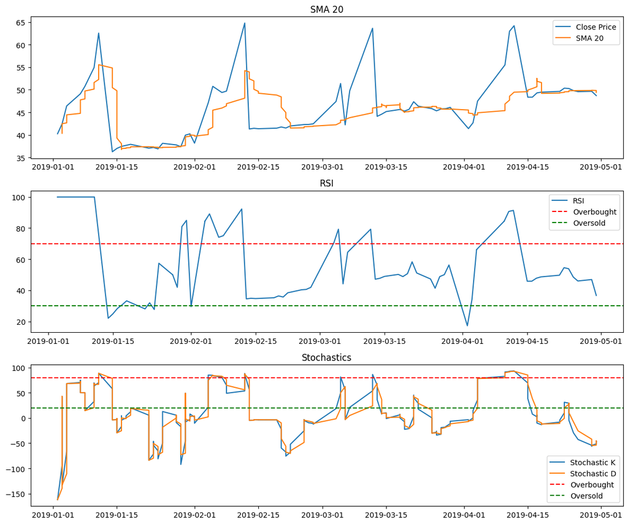

```python
# Create subplots for each indicator
fig, axes = plt.subplots(nrows=3, ncols=1, figsize=(12, 10))

# Plot SMA
axes[0].plot(df['Date'], df['Close'], label='Close Price')
axes[0].plot(df['Date'], df['SMA_20'], label='SMA 20')
axes[0].set_title('SMA 20')
axes[0].legend()

# Plot RSI
axes[1].plot(df['Date'], df['RSI'], label='RSI')
axes[1].axhline(y=70, color='r', linestyle='--', label='Overbought')
axes[1].axhline(y=30, color='g', linestyle='--', label='Oversold')
axes[1].set_title('RSI')
axes[1].legend()

# Plot Stochastics
axes[2].plot(df['Date'], df['Stochastic_K'], label='Stochastic K')
axes[2].plot(df['Date'], df['Stochastic_D'], label='Stochastic D')
axes[2].axhline(y=80, color='r', linestyle='--', label='Overbought')
axes[2].axhline(y=20, color='g', linestyle='--', label='Oversold')
axes[2].set_title('Stochastics')
axes[2].legend()

# Adjust layout and display the plot
plt.tight_layout()
plt.show()
```

observations

look at this chart with no context it appears the stock is going through a lot but you have no idea about how much of a buying or selling opportunity this is.

in seconds this model could give you a news summary and carefully curated severity score based on sound economics possibly even advice from soros bot!

how much alpha is that when you compound this over time and apply it accross is accorss every single indicator or investment vehicle you care about

reccomendations

find someone like me you can pay to grab stock data and news and label in large quantities to capture market dynamics for specific markets industries and companies

i would focus on getting a massive real world dataset filled with real frinnancial news and real stock market data going back hundreds of years labled very carefully by a whole team of economists for news sentimaate analysis using a rigid classification scheme that is battle tested more along the lines of the fin gpt system of scaling of the impact of news focusing more on the ipact of macroeconomic and geopolitically devistating possible news that is outside the implied/historical volitility distibution not only able to limit tail risk by predicting tail risk from rare events in the historical data but also by identifying things that havent happned in the probability distributions of curreent models either because they havent happpneded in the time frame of documented historical stock market finnancial data or because they havent happened yet but have to happpen given the demographic bomb going of and the unwinding of globalization independent of trade wars because of the inability of the us navy to protect commerce thanks to its carrier heavy navy designed for demolition instead of a destroyer based navy and the logic behind globalization being battling an empire that collapsed in 1991...

imagine a world with pirates, wars, mercantalism, colonial empires, all the assumptions the finnancial services sector relies on like population growth and economic growth. the planet doesnt have much more the human race can grow into... capitalism and communism assume growth which will be harder to come by even if some of the integrated supply chains can somehow survive.

in short there is a lot of tail risk inside the current models distribution but there is also a lot of risk that has yet to be priced in because it hasent happened yet or hasnt happened often enough in the limited historic timeframe finnancial data is in. this risk presents also opportuinty and having a data scientist who can demonstrate skill in natural language proccessing finnancial engineering and geopolitical strategy is hard to put a price on given the way things are moving.

in the future i plan on injecting geoploitical risk into financial models using finetuned llms careful cleacing of data/labeling, backtesting in simiilar fasion and adding in agentic systems to integrate finnancial statement analysis as well as how news in different vehicles and assets interact with each other as well.

-

Power Ahead